# Univarient Analysis

## Univarient Analysis Report

Here i am going to analyse each variable in the dataset.

```r
options(scipen = 999)
library(data.table)
data <- fread('dataset_00_with_header.csv')
head(data)
```

```
##       x001 x002 x003 x004 x005 x006 x007 x008 x009 x010 x011 x012 x013
## 1: 1540332   NA   NA   NA    8    1    0    1    0    0    0    0    0
## 2:  823066    4    3    3    4    0    2    2    0    0    0    0    0
## 3: 1089795   NA   NA   NA   96    1    0    0    0    1    3    4    1
## 4: 1147758   63   14   38  258    0    0    0    1    2    1    1    1
## 5: 1229670   34   25   29   34    1    0    0    0    3    0    0    0
## 6: 1292282   NA   NA   NA  126    0    0    0    0    0    1    0    0
##    x014 x015 x016 x017 x018 x019 x020 x021 x022 x023 x024 x025 x026 x027
## 1:    0    1    0    1    1    0    1    0    1    0    0    0    0    1
## 2:    0    2    2    0    2    2    0    0    0    0    2    0    1    0
## 3:    0    9    0    9    2    0    9    0    2    0    0    0    0    1
## 4:    1    7    2    5    5    2    4    1    3    1    3    0    0    1
## 5:    0    3    2    1    2    1    3    2    2    1    0    0    0    1
## 6:    2    3    0    3    2    0    1    0    1    0    2    0    1    0
##    x028 x029 x030 x031 x032 x033 x034 x035 x036 x037 x038 x039 x040   x041
```

[output cut: 146 more lines]

# Dimensions of the data

There are total 100000 records and 305 variables

```r
dim(data)
```

```
## [1] 100000    305
```

**Importing Required Packages**

```r
#install.packages('checkmate')
#install.packages('acepack')
#install.packages('Hmisc')
#install.packages('pastecs')
#install.packages('psych')
library(Hmisc)
library(pastecs)
library(psych)
options(scipen = 999)
```

## variable x001

```r
NROW(unique(data$x001))
```

```
## [1] 100000
```

**Observation:** Hence it is very clear that x001 is like ID

## variable x002

**Summary of the data**

```r
summary(data$x002)
```

```
##    Min. 1st Qu.  Median    Mean 3rd Qu.    Max.    NA's
##     0.0    32.0   100.0   125.7   180.0   718.0   21432
```

Here we found that mean and median are not pretty close and we can say that the distribution of the variable is not approximately normal  
**Missing Values:**  
There are 21432 missing values i.e., 21% of missing values

**Description of the data**

```r
describe(data$x002)
```

```
##    vars     n   mean     sd median trimmed    mad min max range skew
## X1    1 78568 125.71 115.79    100  108.44 105.26   0 718   718 1.31
##    kurtosis   se
## X1     1.65 0.41
```

Here the kurtosis is positive hence there is large data in tails

**Total number of values excluding NA**

```r
NROW(data$x002) - NROW(data[which(is.na(data$x002)),])
```

```
## [1] 78568
```

```r
NROW(data[which(data$x002<=200),])
```

```
## [1] 61934
```

```r
NROW(data[which(data$x002<=300),])
```

```
## [1] 71175
```

## Now visualize the statistics

**Histogram**

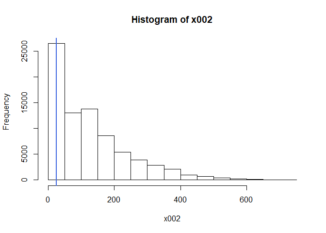

```r
hist(data$x002,
     main = "Histogram of x002",
     xlab = "x002")
abline(v =mean(data$x003, na.rm = TRUE),col = "royalblue",
 lwd = 2)
```

**Boxplot**

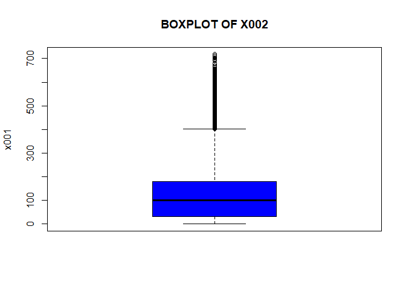

```r
boxplot(data$x002,
        main = toupper("Boxplot of x002"),
        ylab = "x001",
        col = "blue")
```

**Density Plot**

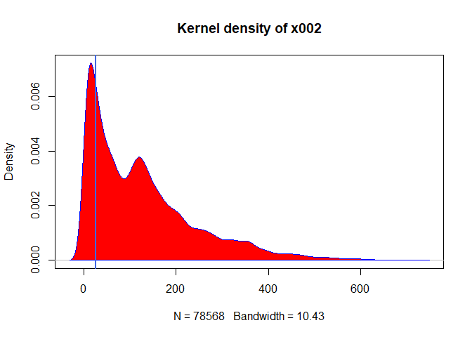

```r
d <- density(data$x002, na.rm = TRUE)
plot(d, main = "Kernel density of x002")
polygon(d, col = "red", border = "blue")
abline(v =mean(data$x003, na.rm = TRUE),col = "royalblue",
 lwd = 2)
```

## variable x003

**Summary of the data**

```r
summary(data$x003)
```

```
##    Min. 1st Qu.  Median    Mean 3rd Qu.    Max.    NA's
##    0.00    3.00    8.00   25.54   24.00  704.00   21432
```

Here we found that mean and median are not pretty close and we can say that the distribution of the variable is not approximately normal  
**Missing Values:**  
There are 21432 missing values i.e., 21% of missing values

**Description of the data**

```r
describe(data$x003)
```

```
##    vars     n  mean    sd median trimmed mad min max range skew kurtosis
## X1    1 78568 25.54 49.03      8   13.73 8.9   0 704   704 4.18    23.95
##      se
## X1 0.17
```

Here the kurtosis is positive hence there is large data in tails

**Total number of values excluding NA**

```r
NROW(data$x003) - NROW(data[which(is.na(data$x003)),])
```

```
## [1] 78568
```

```r
NROW(data[which(data$x003<=50),])
```

```
## [1] 68068
```

```r
NROW(data[which(data$x003<=200),])
```

```
## [1] 77207
```

## Now visualize the statistics

**Histogram**

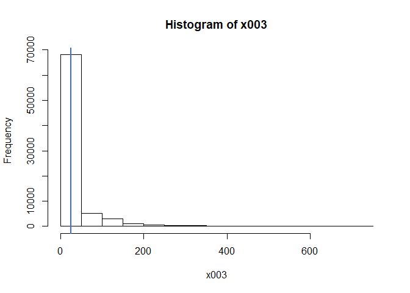

```r
hist(data$x003,
     main = "Histogram of x003",
     xlab = "x003")
abline(v =mean(data$x003, na.rm = TRUE),col = "royalblue",
 lwd = 2)
```

**Boxplot**

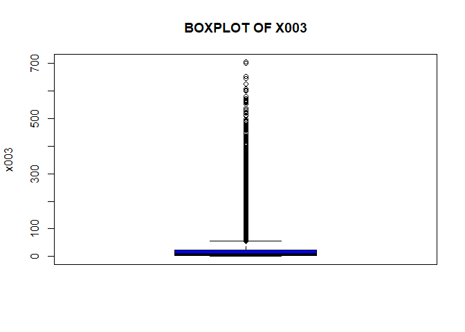

```r
boxplot(data$x003,
        main = toupper("Boxplot of x003"),
        ylab = "x003",
        col = "blue")
abline(v =mean(data$x003, na.rm = TRUE),col = "royalblue",
 lwd = 2)
```

**Density Plot**

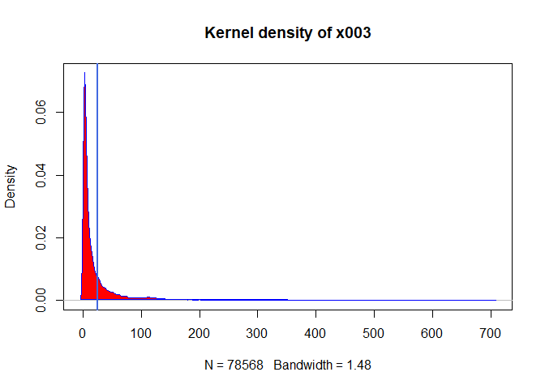

```r
d <- density(data$x003, na.rm = TRUE)
plot(d, main = "Kernel density of x003")
polygon(d, col = "red", border = "blue")
abline(v =mean(data$x003, na.rm = TRUE),col = "royalblue",
 lwd = 2)
```

## variable x004

**Summary of the data**

```r
summary(data$x004)
```

```
##    Min. 1st Qu.  Median    Mean 3rd Qu.    Max.    NA's
##    0.00   19.00   48.00   65.39   92.00  704.00   21424
```

Here we found that mean and median are not close and we can say that the distribution of the variable is not approximately normal  
**Missing Values:**  
There are 21424 missing values i.e., 21% of missing values

**Description of the data**

```r
describe(data$x004)
```

```
##    vars     n  mean    sd median trimmed   mad min max range skew kurtosis
## X1    1 78576 65.39 63.59     48   55.07 48.93   0 704   704 2.01     6.38
##      se
## X1 0.23
```

Here the kurtosis is positive hence there is large data in tails

**Total number of values excluding NA**

```r
NROW(data$x004) - NROW(data[which(is.na(data$x004)),])
```

```
## [1] 78576
```

```r
NROW(data[which(data$x004<=100),])
```

```
## [1] 61513
```

i.e., 78%

```r
NROW(data[which(data$x004<=200),])
```

```
## [1] 75370
```

i.e., 96% ## Now visualize the statistics **Histogram**

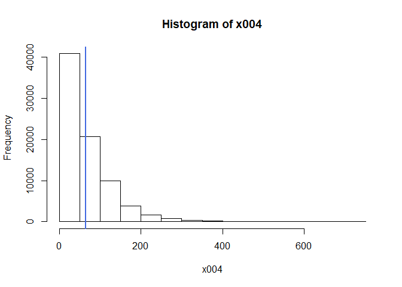

```r
hist(data$x004,
     main = "Histogram of x004",
     xlab = "x004")
abline(v =mean(data$x004, na.rm = TRUE),col = "royalblue",
 lwd = 2)
```

**Boxplot**

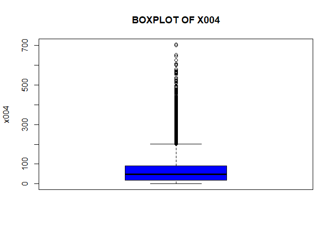

```r
boxplot(data$x004,
        main = toupper("Boxplot of x004"),
        ylab = "x004",
        col = "blue")
abline(v =mean(data$x004, na.rm = TRUE),col = "royalblue",
 lwd = 2)
```

**Density Plot**

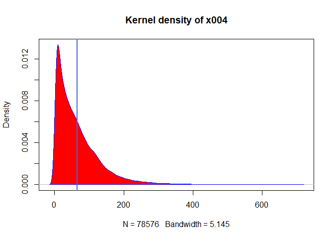

```r
d <- density(data$x004, na.rm = TRUE)
plot(d, main = "Kernel density of x004")
polygon(d, col = "red", border = "blue")
abline(v =mean(data$x004, na.rm = TRUE),col = "royalblue",
 lwd = 2)
```

**Observation:**  
From the above graphs and stats i observed that 78% are below 100 and 96% are below 200.  
There is lot of positive skewness in the data. There are 21% of missing values and i assume that these are not random missing values because x002 and x003 have same number of missing values. This variable have descrete values

## variable x005

**Summary of the data**

```r
summary(data$x005)
```

```
##    Min. 1st Qu.  Median    Mean 3rd Qu.    Max.    NA's
##     0.0    87.0   150.0   178.2   246.0   827.0    6110
```

Here we found that mean and median are not pretty close and we can say that the distribution of the variable is not approximately normal  
**Missing Values:**  
There are 6110 missing values i.e., 6% of missing values

**Description of the data**

```r
describe(data$x005)
```

```
##    vars     n   mean     sd median trimmed    mad min max range skew
## X1    1 93890 178.24 124.52    150  164.84 111.19   0 827   827 1.03
##    kurtosis   se
## X1     0.95 0.41
```

Here the kurtosis is low positive hence there is some data in tails

**Total number of values excluding NA**

```r
NROW(data$x005) - NROW(data[which(is.na(data$x005)),])
```

```
## [1] 93890
```

```r
NROW(data[which(data$x005<=300),])
```

```
## [1] 78689
```

i.e., 83%

```r
NROW(data[which(data$x005<=400),])
```

```
## [1] 88071
```

i.e., 93% ## Now visualize the statistics **Histogram**

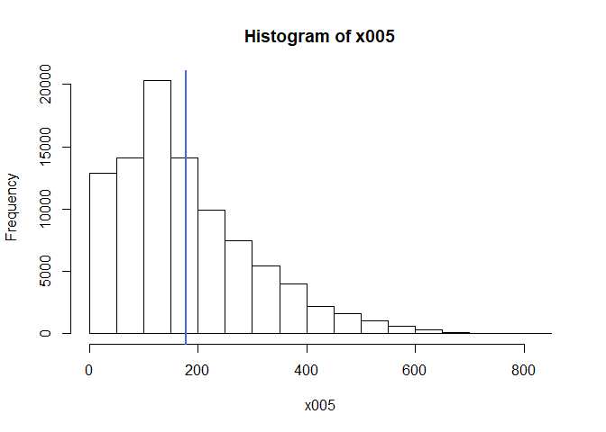

```r
hist(data$x005,
     main = "Histogram of x005",
     xlab = "x005")
abline(v =mean(data$x005, na.rm = TRUE),col = "royalblue",
 lwd = 2)
```

**Boxplot**

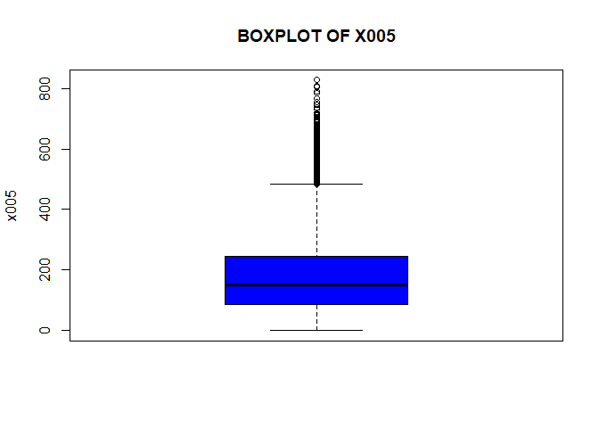

```r
boxplot(data$x005,
        main = toupper("Boxplot of x005"),
        ylab = "x005",
        col = "blue")
abline(v =mean(data$x005, na.rm = TRUE),col = "royalblue",
 lwd = 2)
```

**Density Plot**

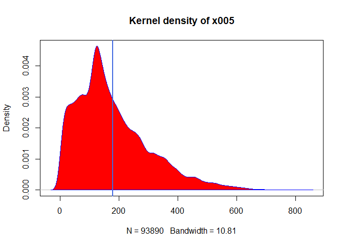

```r
d <- density(data$x005, na.rm = TRUE)
plot(d, main = "Kernel density of x005")
polygon(d, col = "red", border = "blue")
abline(v =mean(data$x005, na.rm = TRUE),col = "royalblue",
 lwd = 2)
```

**Observation:**  
From the above graphs and stats i observed that 83% are below 300 and 93% are below 400.  
There is positive skewness in the data. There is only 6% of missing values and i assume that these are random missing values. This variable have descrete values ____________________________________________________________________________________

## variable x006

**Summary of the data**

```r
summary(data$x006)
```

```
##    Min. 1st Qu.  Median    Mean 3rd Qu.    Max.
##   0.000   0.000   0.000   0.314   1.000   1.000
```

Here it is very clear that this is a Binary variable **Missing Values:**  
There are no missing values

```r
table(data$x006)
```

```
##
##     0     1
## 68596 31404
```

Hence there are 68596 are 0 and 31404 are 1 ## Now visualize the statistics **Histogram**

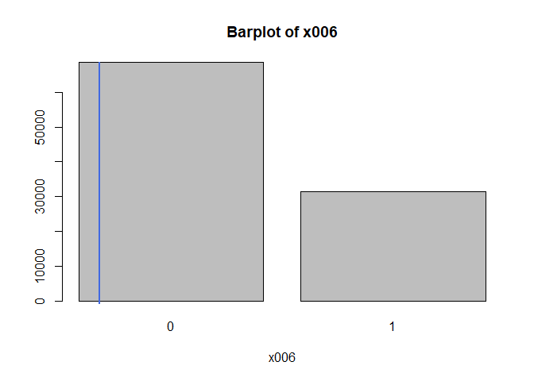

```r
barplot(table(data$x006),
     main = "Barplot of x006",
     xlab = "x006")
abline(v =mean(data$x006, na.rm = TRUE),col = "royalblue",
 lwd = 2)
```

## variable x007

**Summary of the data**

```r
summary(data$x007)
```

```
##    Min. 1st Qu.  Median    Mean 3rd Qu.    Max.
##   0.000   0.000   0.000   0.694   1.000  44.000
```

**Description of the data**

```r
describe(data$x007)
```

```
##    vars      n mean   sd median trimmed mad min max range skew kurtosis se
## X1    1 100000 0.69 1.38      0     0.4   0   0  44    44 5.01    60.03  0
```

Here the kurtosis is very high positive hence there is large data in tails

```r
NROW(data[which(data$x007<=1),])
```

```
## [1] 84259
```

i.e., 84%

```r
NROW(data[which(data$x007<=2),])
```

```
## [1] 92739
```

i.e., 92% ## Now visualize the statistics **Histogram**

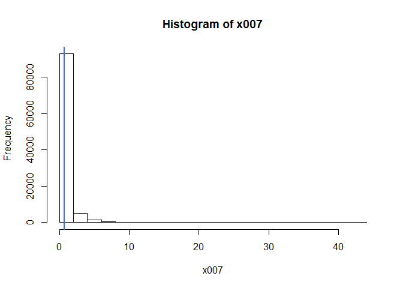

```r
hist(data$x007,
     main = "Histogram of x007",
     xlab = "x007")
abline(v =mean(data$x007, na.rm = TRUE),col = "royalblue",
 lwd = 2)
```

**Boxplot**

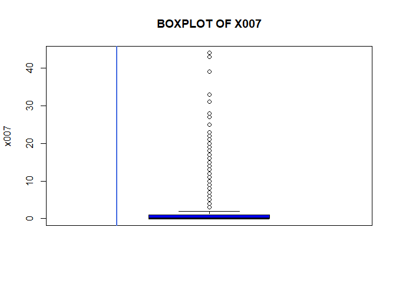

```r
boxplot(data$x007,
        main = toupper("Boxplot of x007"),
        ylab = "x007",
        col = "blue")
abline(v =mean(data$x007, na.rm = TRUE),col = "royalblue",
 lwd = 2)
```

**Density Plot**

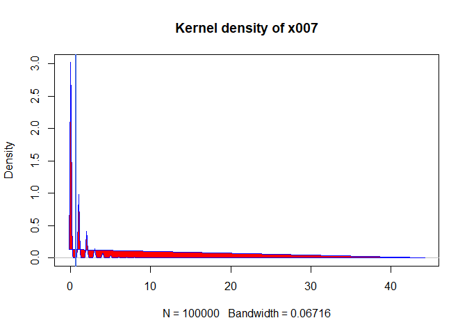

```r
d <- density(data$x007, na.rm = TRUE)
plot(d, main = "Kernel density of x007")
polygon(d, col = "red", border = "blue")
abline(v =mean(data$x007, na.rm = TRUE),col = "royalblue",
 lwd = 2)
```

**Observation:**  
From the above graphs and stats i observed that 84% are below 1 and 92% are below 2.  
There is positive skewness in the data. There are no missing values. This variable have descrete values. We can assume this variable as a categorical variable ____________________________________________________________________________________

## variable x008

**Summary of the data**

```r
summary(data$x008)
```

```
##    Min. 1st Qu.  Median    Mean 3rd Qu.    Max.
##   0.000   0.000   1.000   1.388   2.000 108.000
```

**Description of the data**

```r
describe(data$x008)
```

```
##    vars      n mean   sd median trimmed  mad min max range skew kurtosis
## X1    1 100000 1.39 2.28      1    0.92 1.48   0 108   108 5.04    83.37
##      se
## X1 0.01
```

Here the kurtosis is very high positive hence there is large data in tails

```r
table(data$x008)
```

```
##
##     0     1     2     3     4     5     6     7     8     9    10    11
## 46621 22584 12616  6897  4111  2362  1480   989   677   443   294   221
##    12    13    14    15    16    17    18    19    20    21    22    23
##   156   106    82    78    57    45    37    29    25    14    14    11
##    24    25    26    27    28    29    30    32    33    36    38    39
##     3     8     8     8     2     3     3     2     2     1     1     1
##    40    43    44    46    52    56    60   108
##     1     1     1     2     1     1     1     1
```

```r
NROW(data[which(data$x008<=2),])
```

```
## [1] 81821
```

i.e., 81%

```r
NROW(data[which(data$x008<=5),])
```

```
## [1] 95191
```

i.e., 95% ## Now visualize the statistics **Histogram**

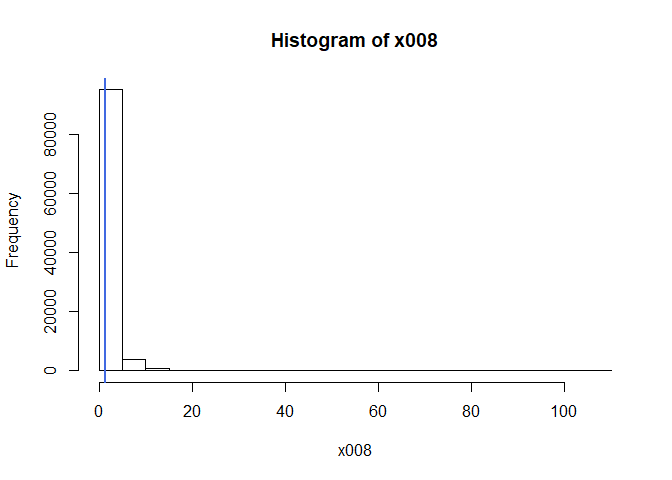

```r
hist(data$x008,
     main = "Histogram of x008",
     xlab = "x008")
abline(v =mean(data$x008, na.rm = TRUE),col = "royalblue",
 lwd = 2)
```

**Boxplot**

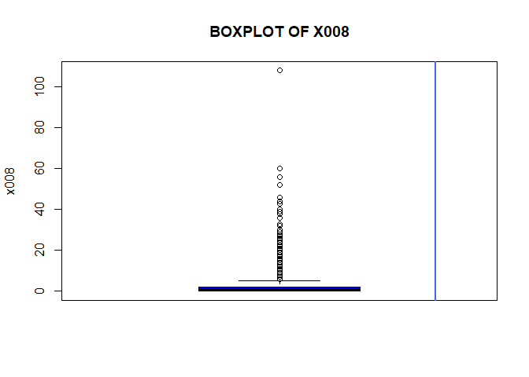

```r
boxplot(data$x008,
        main = toupper("Boxplot of x008"),
        ylab = "x008",
        col = "blue")
abline(v =mean(data$x008, na.rm = TRUE),col = "royalblue",
 lwd = 2)
```

**Density Plot**

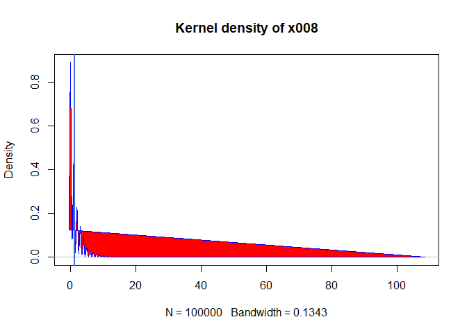

```r
d <- density(data$x008, na.rm = TRUE)
plot(d, main = "Kernel density of x008")
polygon(d, col = "red", border = "blue")
abline(v =mean(data$x008, na.rm = TRUE),col = "royalblue",
 lwd = 2)
```

**Observation:**  
From the above graphs and stats i observed that 81% are below 2 and 95% are below 5.  
There is positive skewness in the data. There are no missing values. This variable have descrete values.

## variable x009

**Summary of the data**

```r
summary(data$x009)
```

```
##    Min. 1st Qu.  Median    Mean 3rd Qu.    Max.
##   0.000   0.000   0.000   1.193   2.000  81.000
```

Here we found that mean and median are not pretty close and we can say that the distribution of the variable is not approximately normal  
**Missing Values:**  
There are no missing values

**Description of the data**

```r
describe(data$x009)
```

```
##    vars      n mean   sd median trimmed mad min max range skew kurtosis
## X1    1 100000 1.19 2.03      0    0.77   0   0  81    81 5.18    80.03
##      se
## X1 0.01
```

Here the kurtosis is very high positive hence there is large data in tails

```r
table(data$x009)
```

```
##
##     0     1     2     3     4     5     6     7     8     9    10    11
## 50814 22003 11676  6281  3560  2073  1214   772   503   317   208   137
##    12    13    14    15    16    17    18    19    20    21    22    23
##    99    63    73    42    29    16    19    16    14     6    12    11
##    24    25    26    27    28    29    31    32    33    34    36    38
##     6     5     3     2     6     2     2     2     2     2     1     1
##    40    41    45    48    78    81
##     2     1     2     1     1     1
```

```r
NROW(data[which(data$x009<=2),])
```

```
## [1] 84493
```

```r
NROW(data[which(data$x009<=5),])
```

```
## [1] 96407
```

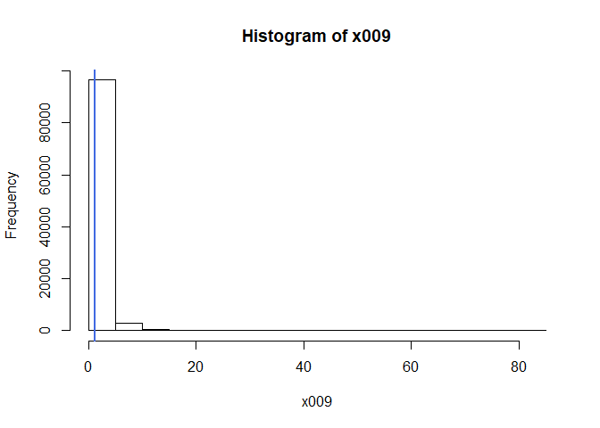

```r
hist(data$x009,
     main = "Histogram of x009",
     xlab = "x009")
abline(v =mean(data$x009, na.rm = TRUE),col = "royalblue",
 lwd = 2)
```

**Boxplot**

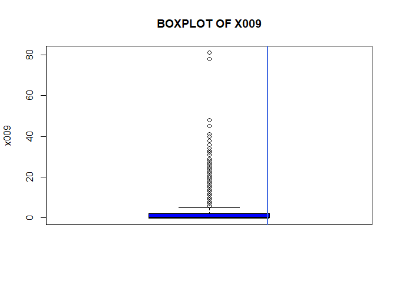

```r
boxplot(data$x009,
        main = toupper("Boxplot of x009"),
        ylab = "x009",
        col = "blue")
abline(v =mean(data$x009, na.rm = TRUE),col = "royalblue",
 lwd = 2)
```

**Density Plot**

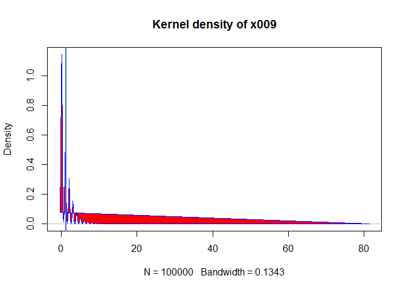

```r
d <- density(data$x009, na.rm = TRUE)
plot(d, main = "Kernel density of x009")
polygon(d, col = "red", border = "blue")
abline(v =mean(data$x009, na.rm = TRUE),col = "royalblue",
 lwd = 2)
```

## variable x010

**Summary of the data**

```r
summary(data$x010)
```

```
##    Min. 1st Qu.  Median    Mean 3rd Qu.    Max.
##   0.000   0.000   0.000   1.027   1.000  33.000
```

Here we found that mean and median are not pretty close and we can say that the distribution of the variable is not approximately normal  
**Missing Values:**  
There are no missing values

**Description of the data**

```r
describe(data$x010)
```

```
##    vars      n mean   sd median trimmed mad min max range skew kurtosis
## X1    1 100000 1.03 1.71      0    0.66   0   0  33    33 3.39    21.28
##      se
## X1 0.01
```

Here the kurtosis is very high positive hence there is large data in tails

```r
table(data$x010)
```

```
##
##     0     1     2     3     4     5     6     7     8     9    10    11
## 54272 21529 11051  5688  3135  1738   967   555   347   222   158    92
##    12    13    14    15    16    17    18    19    20    21    22    23
##    57    47    37    27    24     8     9    11     8     1     2     3
##    24    25    26    27    29    33
##     3     2     3     1     2     1
```

```r
NROW(data[which(data$x010<=2),])
```

```
## [1] 86852
```

```r
NROW(data[which(data$x010<=5),])
```

```
## [1] 97413
```

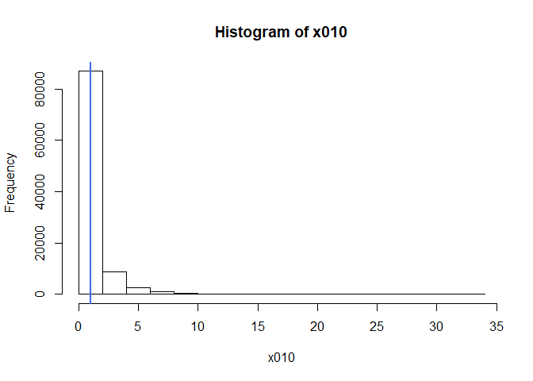

```r
hist(data$x010,
     main = "Histogram of x010",
     xlab = "x010")
abline(v =mean(data$x010, na.rm = TRUE),col = "royalblue",
 lwd = 2)
```

**Boxplot**

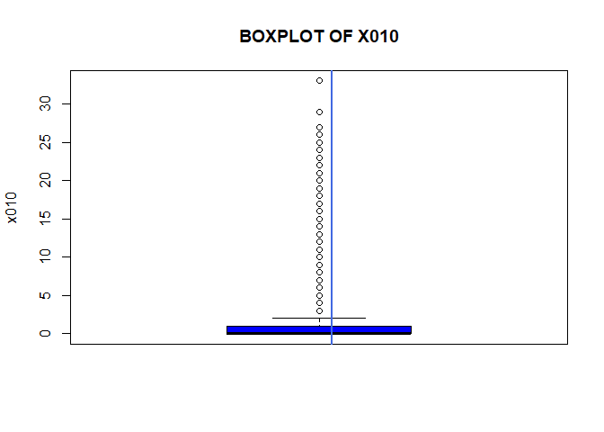

```r
boxplot(data$x010,
        main = toupper("Boxplot of x010"),
        ylab = "x010",
        col = "blue")
abline(v =mean(data$x010, na.rm = TRUE),col = "royalblue",
 lwd = 2)
```

**Density Plot**

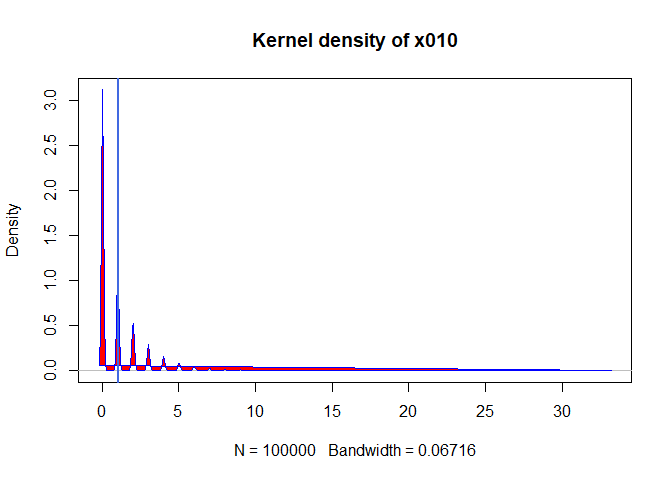

```r
d <- density(data$x010, na.rm = TRUE)
plot(d, main = "Kernel density of x010")
polygon(d, col = "red", border = "blue")
abline(v =mean(data$x010, na.rm = TRUE),col = "royalblue",
 lwd = 2)
```

**Observation:**  
From the above graphs and stats i observed that 86% are below 2 and 97% are below 5, Almost 54% values are 0 .  
There is positive skewness in the data. There are no missing values. This variable have descrete values.

## variable x011

**Summary of the data**

```r
summary(data$x011)
```

```
##    Min. 1st Qu.  Median    Mean 3rd Qu.    Max.
##   0.000   0.000   1.000   1.843   3.000  44.000
```

**Description of the data**

```r
describe(data$x011)
```

```
##    vars      n mean   sd median trimmed  mad min max range skew kurtosis
## X1    1 100000 1.84 2.71      1    1.29 1.48   0  44    44    3    16.04
##      se
## X1 0.01
```

Here the kurtosis is high positive hence there is data in tails

```r
table(data$x011)
```

```
##
##     0     1     2     3     4     5     6     7     8     9    10    11
## 41806 19442 12565  8284  5631  3763  2585  1763  1155   827   571   380
##    12    13    14    15    16    17    18    19    20    21    22    23
##   296   229   175   109    76    63    50    45    41    31    14    17
##    24    25    26    27    28    29    30    31    32    33    34    35
##    17    15    12     4     5     8     3     1     3     2     2     4
##    37    38    39    43    44
##     1     1     1     1     2
```

```r
NROW(data[which(data$x011<=3),])
```

```
## [1] 82097
```

i.e., 82%

```r
NROW(data[which(data$x011<=5),])
```

```
## [1] 91491
```

i.e., 91% ## Now visualize the statistics **Histogram**

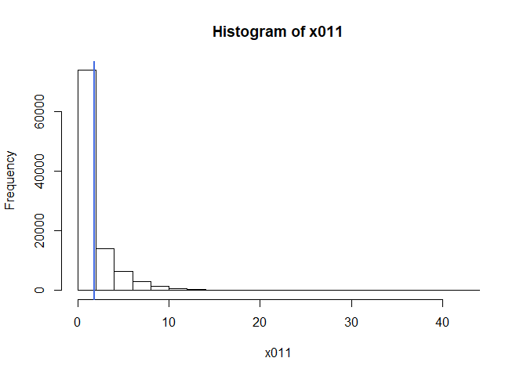

```r
hist(data$x011,
     main = "Histogram of x011",
     xlab = "x011")
abline(v =mean(data$x011, na.rm = TRUE),col = "royalblue",
 lwd = 2)
```

**Boxplot**

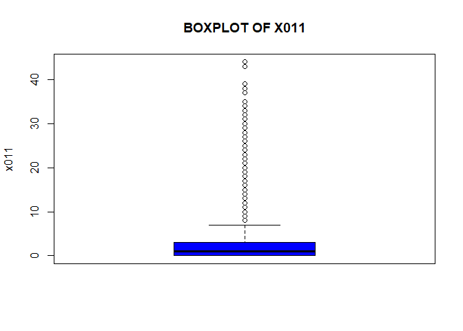

```r
boxplot(data$x011,
        main = toupper("Boxplot of x011"),
        ylab = "x011",
        col = "blue")
abline(v =mean(data$x011, na.rm = TRUE),col = "royalblue",
 lwd = 2)
```

**Density Plot**

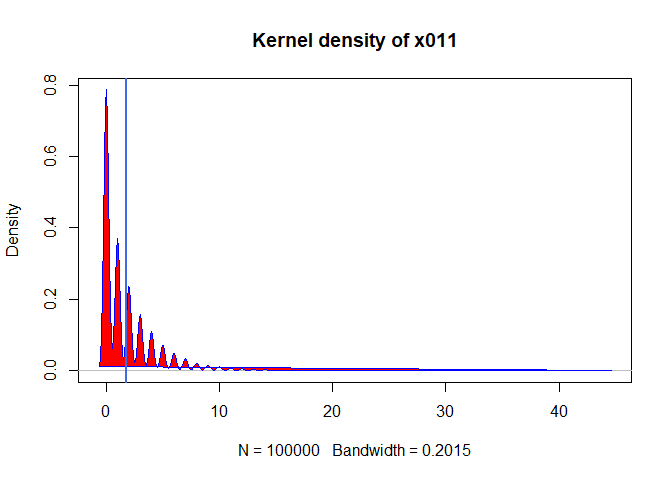

```r
d <- density(data$x011, na.rm = TRUE)
plot(d, main = "Kernel density of x011")
polygon(d, col = "red", border = "blue")
abline(v =mean(data$x011, na.rm = TRUE),col = "royalblue",
 lwd = 2)
```

**Observation:**  
From the above graphs and stats i observed that 82% are below 3 and 91% are below 5, Almost 41% values are 0 .  
There is positive skewness in the data. There are no missing values. This variable have descrete values.

## variable x012

**Summary of the data**

```r
summary(data$x012)
```

```
##    Min. 1st Qu.  Median    Mean 3rd Qu.    Max.
##   0.000   0.000   1.000   1.608   2.000  44.000
```

**Description of the data**

```r
describe(data$x012)
```

```
##    vars      n mean   sd median trimmed  mad min max range skew kurtosis
## X1    1 100000 1.61 2.58      1    1.05 1.48   0  44    44 3.23    18.07
##      se
## X1 0.01
```

Here the kurtosis is high positive hence there is data in tails

```r
table(data$x012)
```

```
##
##     0     1     2     3     4     5     6     7     8     9    10    11
## 47713 18363 11365  7292  4976  3156  2209  1369  1007   671   470   339
##    12    13    14    15    16    17    18    19    20    21    22    23
##   237   196   136   106    75    83    51    37    28    15    12    20
##    24    25    26    27    28    29    30    31    32    34    35    36
##    12    17    11     7     3     6     3     2     5     2     2     1
##    43    44
##     1     2
```

```r
NROW(data[which(data$x012<=3),])
```

```
## [1] 84733
```

i.e., 84%

```r
NROW(data[which(data$x012<=5),])
```

```
## [1] 92865
```

i.e., 92% ## Now visualize the statistics **Histogram**

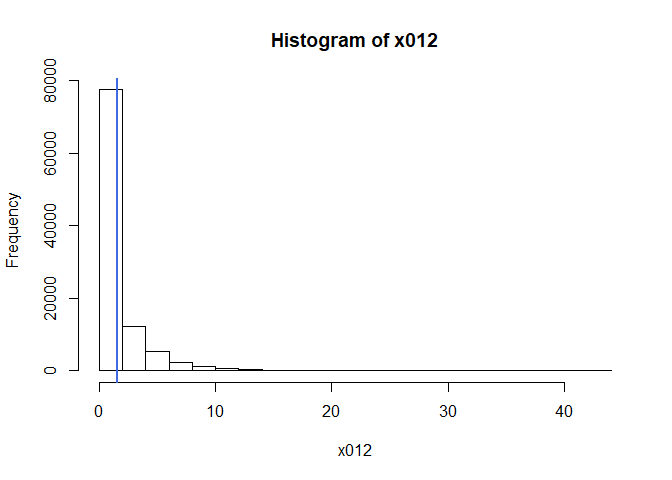

```r
hist(data$x012,
     main = "Histogram of x012",
     xlab = "x012")
abline(v =mean(data$x012, na.rm = TRUE),col = "royalblue",
 lwd = 2)
```

**Boxplot**

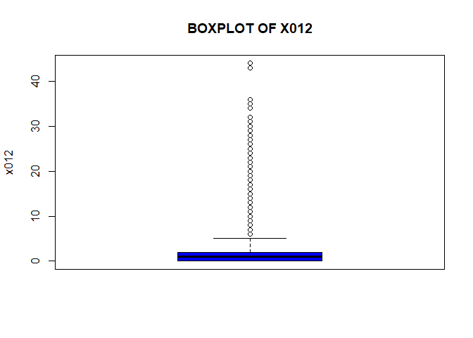

```r
boxplot(data$x012,
        main = toupper("Boxplot of x012"),
        ylab = "x012",
        col = "blue")
abline(v =mean(data$x012, na.rm = TRUE),col = "royalblue",
 lwd = 2)
```

**Density Plot**

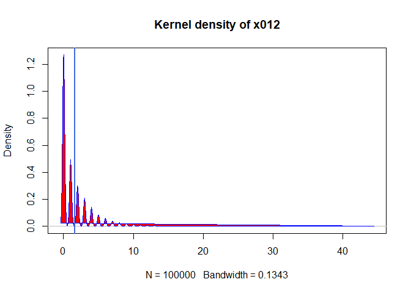

```r
d <- density(data$x012, na.rm = TRUE)
plot(d, main = "Kernel density of x012")
polygon(d, col = "red", border = "blue")
abline(v =mean(data$x012, na.rm = TRUE),col = "royalblue",
 lwd = 2)
```

## variable x013

**Summary of the data**

```r
summary(data$x013)
```

```
##    Min. 1st Qu.  Median    Mean 3rd Qu.    Max.
##   0.000   0.000   0.000   1.577   2.000  42.000
```

Here we found that mean and median are not pretty close and we can say that the distribution of the variable is not approximately normal  
**Missing Values:**  
There are no missing values

**Description of the data**

```r
describe(data$x013)
```

```
##    vars      n mean   sd median trimmed mad min max range skew kurtosis
## X1    1 100000 1.58 2.61      0    1.01   0   0  42    42 3.16    17.16
##      se
## X1 0.01
```

Here the kurtosis is high positive hence there is data in tails

```r
table(data$x013)
```

```
##
##     0     1     2     3     4     5     6     7     8     9    10    11
## 50924 16171 10459  6870  4921  3344  2190  1454  1006   727   456   384
##    12    13    14    15    16    17    18    19    20    21    22    23
##   282   211   124   100    86    69    43    25    31    29    20    17
##    24    25    26    27    28    29    30    32    33    34    36    37
##     7    11     3     7     3     3     4     2     6     4     2     1
##    39    41    42
##     2     1     1
```

```r
NROW(data[which(data$x013<=3),])
```

```
## [1] 84424
```

i.e., 84%

```r
NROW(data[which(data$x013<=5),])
```

```
## [1] 92689
```

i.e., 92% ## Now visualize the statistics **Histogram**

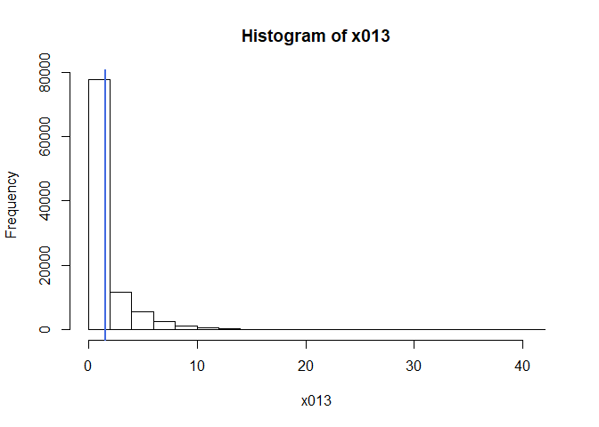

```r
hist(data$x013,
     main = "Histogram of x013",
     xlab = "x013")
abline(v =mean(data$x013, na.rm = TRUE),col = "royalblue",
 lwd = 2)
```

**Boxplot**

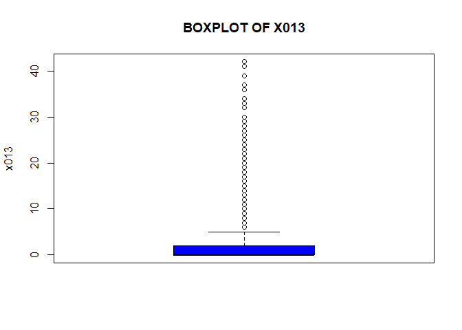

```r
boxplot(data$x013,
        main = toupper("Boxplot of x013"),
        ylab = "x013",
        col = "blue")
abline(v =mean(data$x013, na.rm = TRUE),col = "royalblue",
 lwd = 2)
```

**Density Plot**

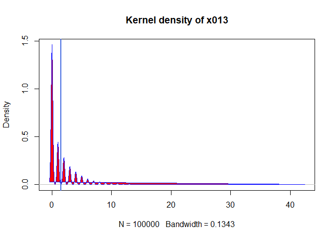

```r
d <- density(data$x013, na.rm = TRUE)
plot(d, main = "Kernel density of x013")
polygon(d, col = "red", border = "blue")
abline(v =mean(data$x013, na.rm = TRUE),col = "royalblue",
 lwd = 2)
```

**Observation:**  
From the above graphs and stats i observed that 84% are below 3 and 92% are below 5, Almost 50% values are 0 .  
There is positive skewness in the data. There are no missing values. This variable have descrete values.

## variable x014

**Summary of the data**

```r
summary(data$x014)
```

```
##    Min. 1st Qu.  Median    Mean 3rd Qu.    Max.
##   0.000   0.000   2.000   4.307   7.000  68.000
```

Here we found that mean and median are not pretty close and we can say that the distribution of the variable is not approximately normal  
**Missing Values:**  
There are no missing values

**Description of the data**

```r
describe(data$x014)
```

```
##    vars      n mean   sd median trimmed  mad min max range skew kurtosis
## X1    1 100000 4.31 5.47      2     3.3 2.97   0  68    68 1.84     5.11
##      se
## X1 0.02
```

Here the kurtosis is positive hence there is data in tails

```r
table(data$x014)
```

```
##
##     0     1     2     3     4     5     6     7     8     9    10    11
## 35222 10392  6965  5743  5376  4894  4547  4108  3678  3196  2819  2428
##    12    13    14    15    16    17    18    19    20    21    22    23
##  2043  1543  1318  1112   846   715   580   496   397   282   221   207
##    24    25    26    27    28    29    30    31    32    33    34    35
##   141   140   108    75    70    48    62    39    23    27    26    14
##    36    37    38    39    40    41    42    43    44    45    46    47
##    18    17    12     6     7     3     5     3     4     2     2     1
##    48    49    50    51    52    53    55    57    60    62    63    68
##     1     2     4     1     1     1     3     2     1     1     1     1
```

```r
NROW(data[which(data$x014<=10),])
```

```
## [1] 86940
```

i.e., 86%

```r
NROW(data[which(data$x014<=20),])
```

```
## [1] 98418
```

i.e., 98% ## Now visualize the statistics **Histogram**

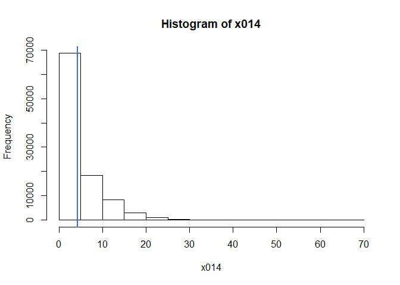

```r
hist(data$x014,
     main = "Histogram of x014",
     xlab = "x014")
abline(v =mean(data$x014, na.rm = TRUE),col = "royalblue",
 lwd = 2)
```

**Boxplot**

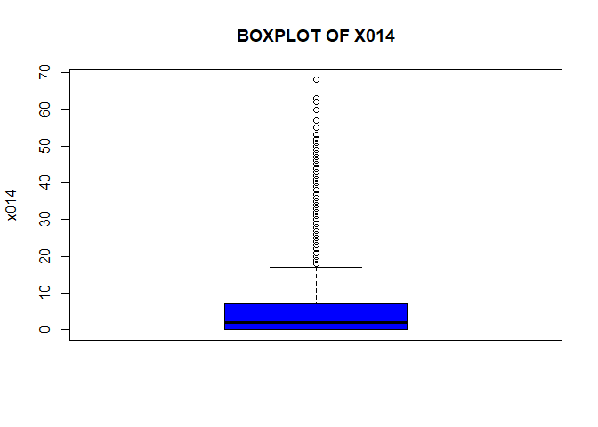

```r
boxplot(data$x014,
        main = toupper("Boxplot of x014"),
        ylab = "x014",
        col = "blue")
abline(v =mean(data$x014, na.rm = TRUE),col = "royalblue",
 lwd = 2)
```

**Density Plot**

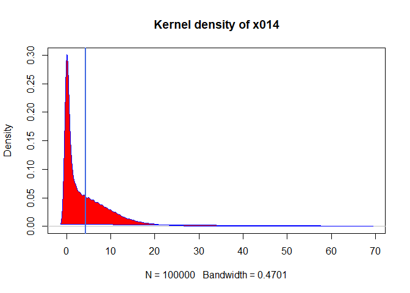

```r
d <- density(data$x014, na.rm = TRUE)
plot(d, main = "Kernel density of x014")
polygon(d, col = "red", border = "blue")
abline(v =mean(data$x014, na.rm = TRUE),col = "royalblue",
 lwd = 2)
```

**Observation:**  
From the above graphs and stats i observed that 86% are below 10 and 98% are below 20.  
There is positive skewness in the data. There are no missing values. This variable have descrete values.

## variable x015

**Summary of the data**

```r
summary(data$x015)
```

```
##    Min. 1st Qu.  Median    Mean 3rd Qu.    Max.
##    0.00    4.00   10.00   12.94   19.00  189.00
```

**Description of the data**

```r
describe(data$x015)
```

```
##    vars      n  mean    sd median trimmed   mad min max range skew
## X1    1 100000 12.94 11.96     10   11.25 10.38   0 189   189 1.78
##    kurtosis   se
## X1     6.19 0.04
```

```r
table(data$x015)
```

```
##
##    0    1    2    3    4    5    6    7    8    9   10   11   12   13   14
## 6107 6522 5823 5112 4721 4334 4104 3875 3803 3650 3507 3384 3353 3197 2970
##   15   16   17   18   19   20   21   22   23   24   25   26   27   28   29
## 2713 2556 2453 2325 2108 1977 1810 1802 1622 1458 1372 1230 1140 1030  933
##   30   31   32   33   34   35   36   37   38   39   40   41   42   43   44
##  808  805  674  618  592  488  485  457  396  310  302  305  243  245  188
##   45   46   47   48   49   50   51   52   53   54   55   56   57   58   59
##  173  174  147  137  128  111  101   99   90   79   70   69   73   53   46
##   60   61   62   63   64   65   66   67   68   69   70   71   72   73   74
##   47   27   28   40   32   25   23   22   12   27   18   15   17   10   16
##   75   76   77   78   79   80   81   82   83   84   85   86   87   88   89
##   13   13    7   12    8   10    5    7    7    9    8    6    1    6    7
##   90   91   93   94   95   96   97   98   99  100  101  102  104  105  106
##    6    2    1    1    1    2    1    2    3    2    4    1    2    3    2
##  107  109  112  113  116  118  119  120  122  123  124  125  126  127  129
##    1    1    1    3    1    1    3    1    3    2    4    3    1    1    1
##  130  134  136  138  189
##    1    1    1    1    1
```

```r
NROW(data[which(data$x015<=25),])
```

```
## [1] 86658
```

i.e., 86%

```r
NROW(data[which(data$x015<=50),])
```

```
## [1] 98777
```

i.e., 98% ## Now visualize the statistics **Histogram**

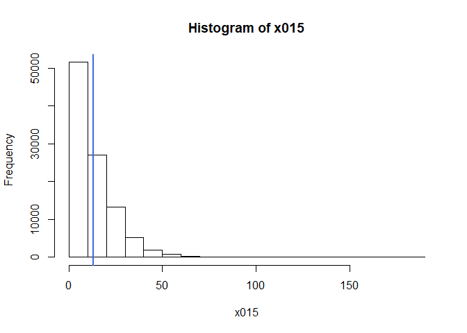

```r
hist(data$x015,
     main = "Histogram of x015",
     xlab = "x015")
abline(v =mean(data$x015, na.rm = TRUE),col = "royalblue",
 lwd = 2)
```

**Boxplot**

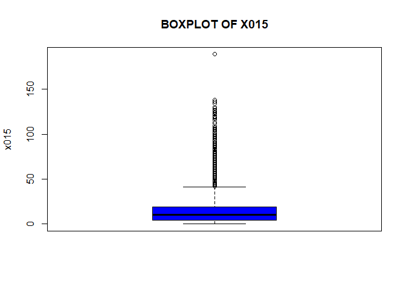

```r
boxplot(data$x015,
        main = toupper("Boxplot of x015"),
        ylab = "x015",
        col = "blue")
abline(v =mean(data$x015, na.rm = TRUE),col = "royalblue",
 lwd = 2)
```

**Density Plot**

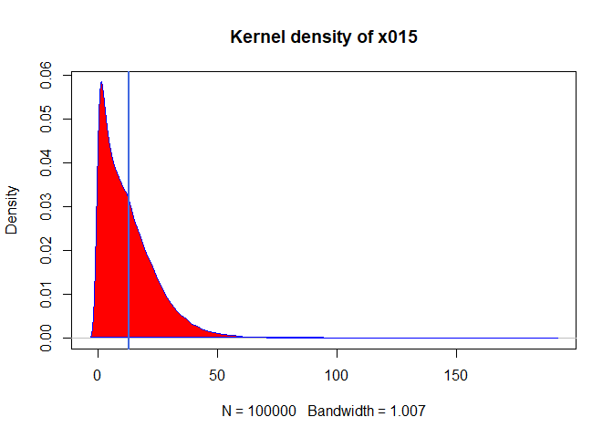

```r
d <- density(data$x015, na.rm = TRUE)
plot(d, main = "Kernel density of x015")
polygon(d, col = "red", border = "blue")
abline(v =mean(data$x015, na.rm = TRUE),col = "royalblue",
 lwd = 2)
```

**Observation:**  
From the above graphs and stats i observed that 86% are below 25 and 98% are below 50.  
There is positive skewness in the data. There are no missing values. This variable have descrete values.

## variable x016

**Summary of the data**

```r
summary(data$x016)
```

```
##    Min. 1st Qu.  Median    Mean 3rd Qu.    Max.
##   0.000   1.000   3.000   4.089   6.000  87.000
```

**Description of the data**

```r
describe(data$x016)
```

```
##    vars      n mean   sd median trimmed  mad min max range skew kurtosis
## X1    1 100000 4.09 4.62      3    3.29 2.97   0  87    87 2.33    10.52
##      se
## X1 0.01
```

Here the kurtosis is positive hence there is data in tails

```r
table(data$x016)
```

```
##
##     0     1     2     3     4     5     6     7     8     9    10    11
## 21424 13820 11627 10113  8770  7184  5708  4421  3520  2774  2116  1714
##    12    13    14    15    16    17    18    19    20    21    22    23
##  1318  1038   826   652   555   462   367   274   226   206   155   123
##    24    25    26    27    28    29    30    31    32    33    34    35
##   110    90    83    50    35    25    32    26    26    20    18    14
##    36    37    38    39    40    41    42    43    44    45    46    47
##     8     4     9     6     4     5     4     6     5     7     3     2
##    48    49    50    51    56    57    60    62    81    87
##     1     4     2     1     1     1     1     2     1     1
```

```r
NROW(data[which(data$x016<=7),])
```

```
## [1] 83067
```

i.e., 83%

```r
NROW(data[which(data$x016<=20),])
```

```
## [1] 98909
```

i.e., 98% ## Now visualize the statistics **Histogram**

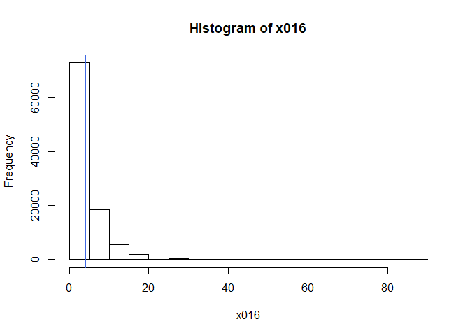

```r
hist(data$x016,
     main = "Histogram of x016",
     xlab = "x016")
abline(v =mean(data$x016, na.rm = TRUE),col = "royalblue",
 lwd = 2)
```

**Boxplot**

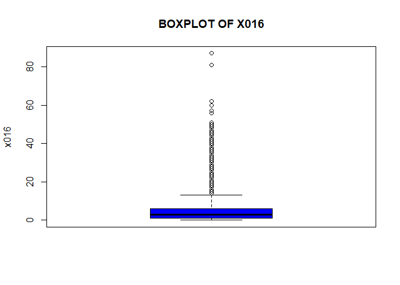

```r
boxplot(data$x016,
        main = toupper("Boxplot of x016"),
        ylab = "x016",
        col = "blue")
abline(v =mean(data$x016, na.rm = TRUE),col = "royalblue",
 lwd = 2)
```

**Density Plot**

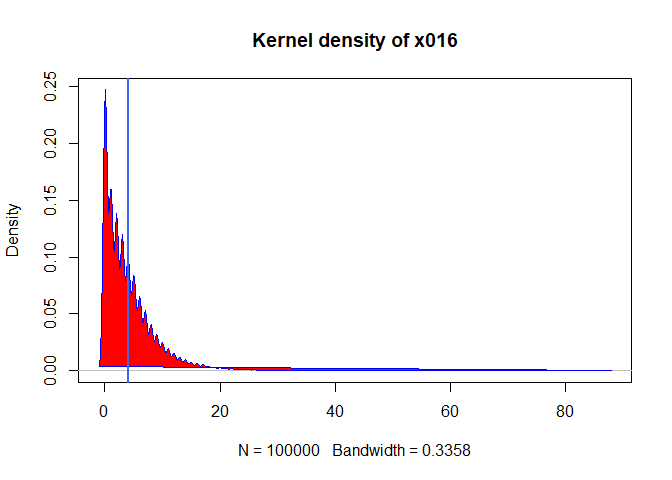

```r
d <- density(data$x016, na.rm = TRUE)
plot(d, main = "Kernel density of x016")
polygon(d, col = "red", border = "blue")
abline(v =mean(data$x016, na.rm = TRUE),col = "royalblue",
 lwd = 2)
```

## variable x017

**Summary of the data**

```r
summary(data$x017)
```

```
##    Min. 1st Qu.  Median    Mean 3rd Qu.    Max.
##   0.000   2.000   6.000   8.854  13.000 162.000
```

Here we found that mean and median are not pretty close and we can say that the distribution of the variable is not approximately normal  
**Missing Values:**  
There are no missing values

**Description of the data**

```r
describe(data$x017)
```

```
##    vars      n mean   sd median trimmed  mad min max range skew kurtosis
## X1    1 100000 8.85 9.25      6    7.38 7.41   0 162   162 2.24    10.26
##      se
## X1 0.03
```

Here the kurtosis is positive hence there is data in tails

```r
table(data$x017)
```

```
##
##     0     1     2     3     4     5     6     7     8     9    10    11
## 11025  9519  7800  6642  5955  5383  4972  4515  4293  3905  3684  3437
##    12    13    14    15    16    17    18    19    20    21    22    23
##  3040  2767  2478  2266  2019  1785  1638  1460  1338  1172   988   956
##    24    25    26    27    28    29    30    31    32    33    34    35
##   783   682   619   542   465   438   370   335   303   261   216   189
##    36    37    38    39    40    41    42    43    44    45    46    47
##   172   170   135   124   122    92    97    76    71    66    51    40
##    48    49    50    51    52    53    54    55    56    57    58    59
##    60    35    39    41    25    27    19    24    19    13    25    14
##    60    61    62    63    64    65    66    67    68    69    70    71
##    12    12    15    11    12     6    11    10     9     7     4     4
##    72    73    74    75    76    77    78    79    80    81    82    83
##     8     3     4     6     4     4     4     3     4     3     3     1
##    84    85    87    88    90    91    93    94    95    99   101   102
##     1     2     1     2     1     4     2     3     2     1     3     2
##   103   106   108   110   111   113   116   117   118   119   121   122
##     2     2     1     1     1     2     1     1     3     1     1     1
##   123   162
##     1     1
```

```r
NROW(data[which(data$x017<=15),])
```

```
## [1] 81681
```

i.e., 81%

```r
NROW(data[which(data$x017<=25),])
```

```
## [1] 94502
```

i.e., 94% ## Now visualize the statistics **Histogram**

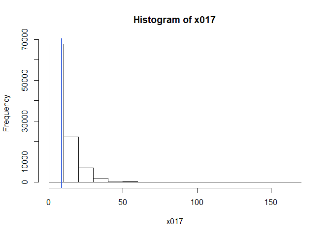

```r
hist(data$x017,
     main = "Histogram of x017",
     xlab = "x017")
abline(v =mean(data$x017, na.rm = TRUE),col = "royalblue",
 lwd = 2)
```

**Boxplot**

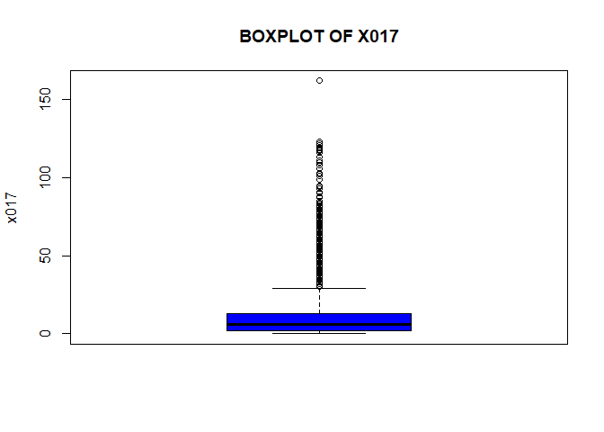

```r
boxplot(data$x017,
        main = toupper("Boxplot of x017"),
        ylab = "x017",
        col = "blue")
abline(v =mean(data$x017, na.rm = TRUE),col = "royalblue",
 lwd = 2)
```

**Density Plot**

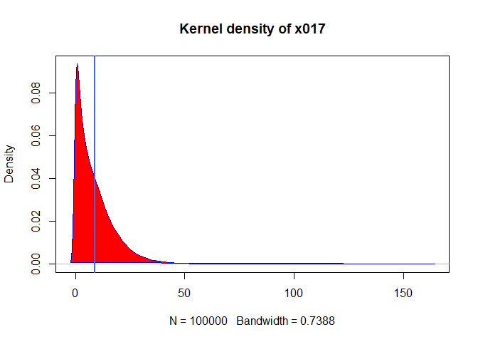

```r
d <- density(data$x017, na.rm = TRUE)
plot(d, main = "Kernel density of x017")
polygon(d, col = "red", border = "blue")
abline(v =mean(data$x017, na.rm = TRUE),col = "royalblue",
 lwd = 2)
```

**Observation:**  
From the above graphs and stats i observed that 81% are below 15 and 94% are below 25.  
There is positive skewness in the data. There are no missing values. This variable have descrete values.

Since there are 304 variables i will represent every variable visually

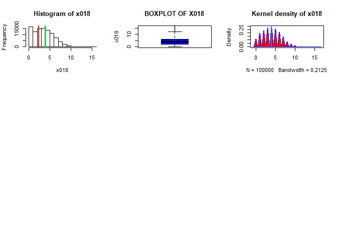

```r
par(mfrow=c(3,3))
hist(data$x018,
     main = "Histogram of x018",
     xlab = "x018")
abline(v =mean(data$x018, na.rm = TRUE),col = "royalblue",
       lwd = 2)
abline(v =median(data$x018, na.rm = TRUE),col = "green",
       lwd = 2)
abline(v =sd(data$x018, na.rm = TRUE),col = "red",
       lwd = 2)
boxplot(data$x018,
        main = toupper("Boxplot of x018"),
        ylab = "x018",
        col = "blue")
abline(v =mean(data$x018, na.rm = TRUE),col = "royalblue",
       lwd = 2)
d <- density(data$x018, na.rm = TRUE)
plot(d, main = "Kernel density of x018")
polygon(d, col = "red", border = "blue")
abline(v =mean(data$x018, na.rm = TRUE),col = "royalblue",
       lwd = 2)
```

## Variable x019

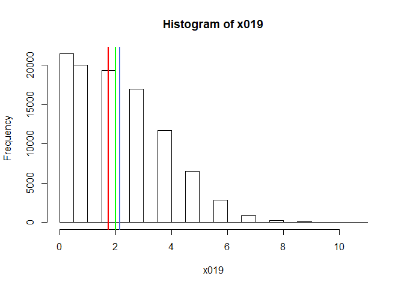

```r
hist(data$x019,
     main = "Histogram of x019",
     xlab = "x019")
abline(v =mean(data$x019, na.rm = TRUE),col = "royalblue",
       lwd = 2)
abline(v =median(data$x019, na.rm = TRUE),col = "green",
       lwd = 2)
abline(v =sd(data$x019, na.rm = TRUE),col = "red",
       lwd = 2)
```

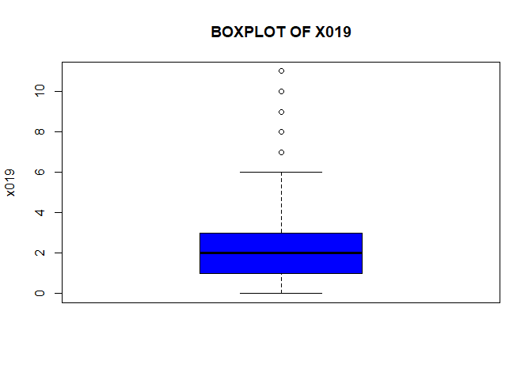

```r
boxplot(data$x019,
        main = toupper("Boxplot of x019"),
        ylab = "x019",
        col = "blue")
abline(v =mean(data$x019, na.rm = TRUE),col = "royalblue",
       lwd = 2)
```

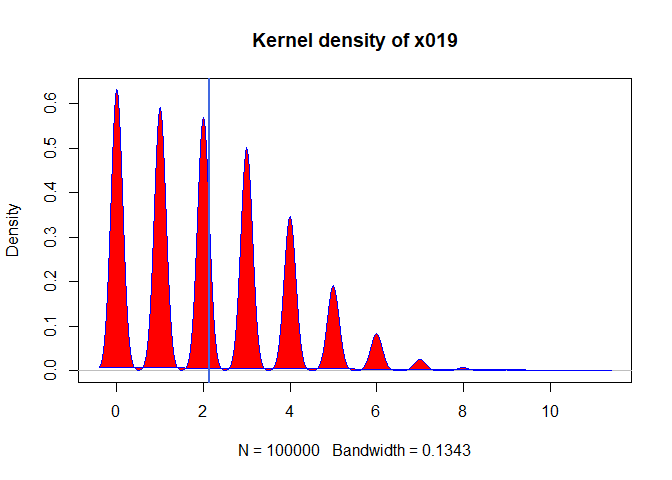

```r
d <- density(data$x019, na.rm = TRUE)
plot(d, main = "Kernel density of x019")
polygon(d, col = "red", border = "blue")
abline(v =mean(data$x019, na.rm = TRUE),col = "royalblue",
       lwd = 2)
```

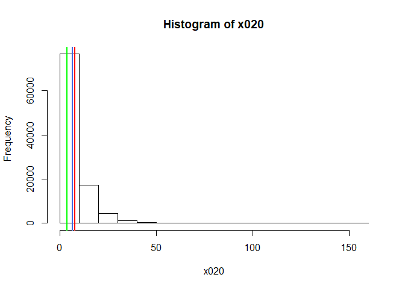

```r
hist(data$x020,
     main = "Histogram of x020",
     xlab = "x020")
abline(v =mean(data$x020, na.rm = TRUE),col = "royalblue",
       lwd = 2)
abline(v =median(data$x020, na.rm = TRUE),col = "green",
       lwd = 2)
abline(v =sd(data$x020, na.rm = TRUE),col = "red",
       lwd = 2)
```

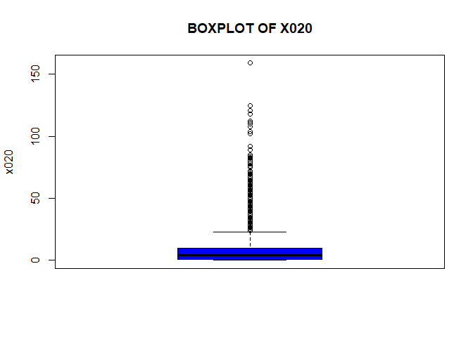

```r
boxplot(data$x020,
        main = toupper("Boxplot of x020"),
        ylab = "x020",
        col = "blue")
abline(v =mean(data$x020, na.rm = TRUE),col = "royalblue",
       lwd = 2)
```

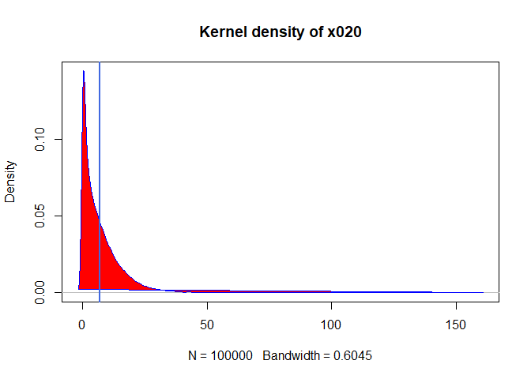

```r
d <- density(data$x020, na.rm = TRUE)
plot(d, main = "Kernel density of x020")
polygon(d, col = "red", border = "blue")
abline(v =mean(data$x020, na.rm = TRUE),col = "royalblue",
       lwd = 2)
```

## Variable x021

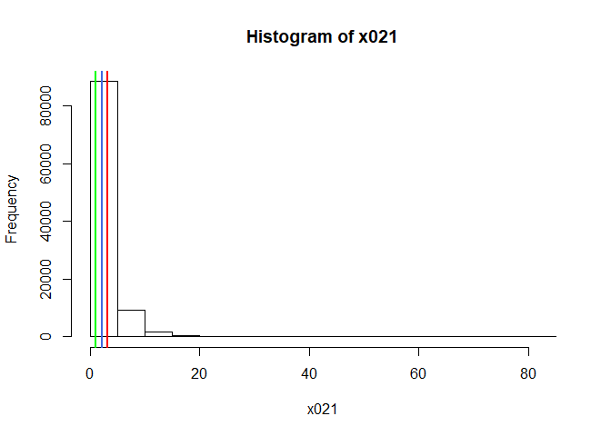

```r
hist(data$x021,
     main = "Histogram of x021",
     xlab = "x021")
abline(v =mean(data$x021, na.rm = TRUE),col = "royalblue",
       lwd = 2)
abline(v =median(data$x021, na.rm = TRUE),col = "green",
       lwd = 2)
abline(v =sd(data$x021, na.rm = TRUE),col = "red",
       lwd = 2)
```

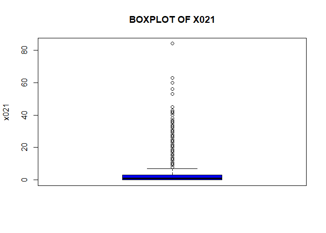

```r
boxplot(data$x021,
        main = toupper("Boxplot of x021"),
        ylab = "x021",
        col = "blue")
abline(v =mean(data$x021, na.rm = TRUE),col = "royalblue",
       lwd = 2)
```

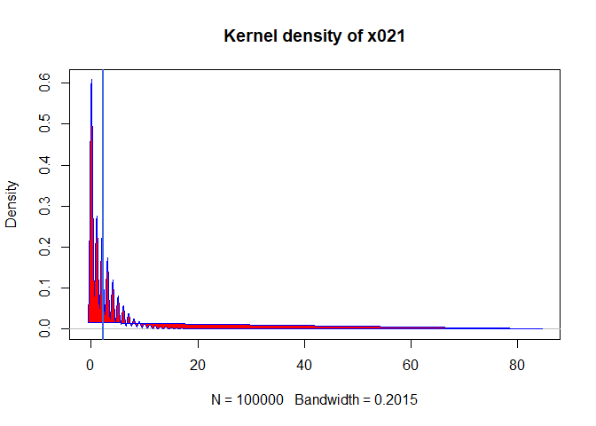

```r
d <- density(data$x021, na.rm = TRUE)
plot(d, main = "Kernel density of x021")
polygon(d, col = "red", border = "blue")
abline(v =mean(data$x021, na.rm = TRUE),col = "royalblue",
       lwd = 2)
```

## Variable x022

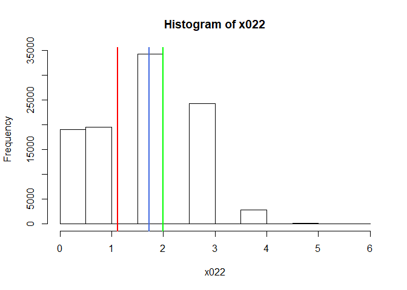

```r
hist(data$x022,
     main = "Histogram of x022",
     xlab = "x022")
abline(v =mean(data$x022, na.rm = TRUE),col = "royalblue",
       lwd = 2)
abline(v =median(data$x022, na.rm = TRUE),col = "green",
       lwd = 2)
abline(v =sd(data$x022, na.rm = TRUE),col = "red",
       lwd = 2)
```

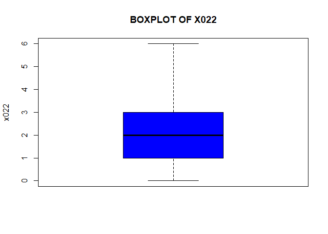

```r
boxplot(data$x022,
        main = toupper("Boxplot of x022"),
        ylab = "x022",
        col = "blue")
abline(v =mean(data$x022, na.rm = TRUE),col = "royalblue",
       lwd = 2)
```

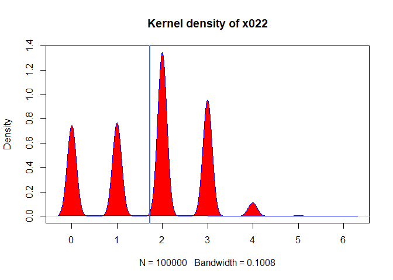

```r
d <- density(data$x022, na.rm = TRUE)
plot(d, main = "Kernel density of x022")
polygon(d, col = "red", border = "blue")
abline(v =mean(data$x022, na.rm = TRUE),col = "royalblue",
       lwd = 2)
```

## Variable x023

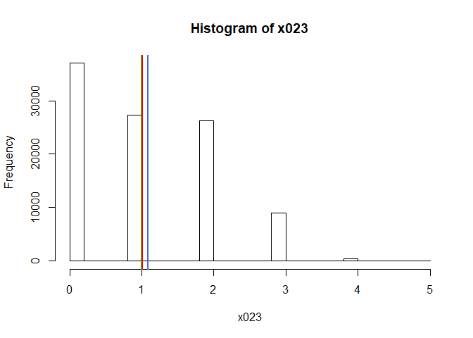

```r
hist(data$x023,
     main = "Histogram of x023",
     xlab = "x023")
abline(v =mean(data$x023, na.rm = TRUE),col = "royalblue",
       lwd = 2)
abline(v =median(data$x023, na.rm = TRUE),col = "green",
       lwd = 2)
abline(v =sd(data$x023, na.rm = TRUE),col = "red",
       lwd = 2)
```

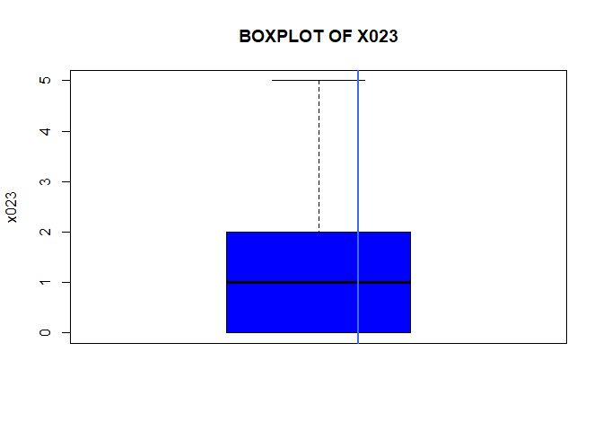

```r
boxplot(data$x023,
        main = toupper("Boxplot of x023"),
        ylab = "x023",
        col = "blue")
abline(v =mean(data$x023, na.rm = TRUE),col = "royalblue",
       lwd = 2)
```

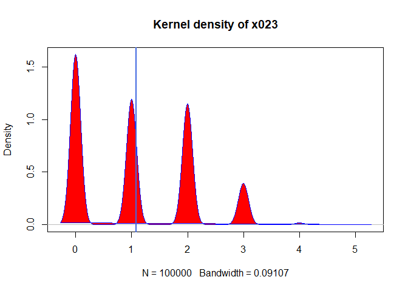

```r
d <- density(data$x023, na.rm = TRUE)
plot(d, main = "Kernel density of x023")
polygon(d, col = "red", border = "blue")
abline(v =mean(data$x023, na.rm = TRUE),col = "royalblue",
       lwd = 2)
```